# Week 9

Shuntai Zhou

2022-05-10

# Data Analysis

- Week 9: Continuous data
- Week 10: Linear regression
- Week 11: Categorical data
- Week 12: Logistic regression
- Week 13: Time-to-event data and survival

## Continous Data

- Continuous data can be measured
- Categorical data can be counted

### Get and check the data

```r
# Load packages
library(tidyverse)
library(ggpubr)
library(finalfit)
library(gapminder)
theme_set(theme_bw())

# Create object gapdata from object gapminder
gapdata <- gapminder
```

Take a quick look at the data and check missing data.

```r
glimpse(gapdata)
```

```
## Rows: 1,704
## Columns: 6
## $ country   <fct> "Afghanistan", "Afghanistan", "Afghanistan", "Afghanistan", …
## $ continent <fct> Asia, Asia, Asia, Asia, Asia, Asia, Asia, Asia, Asia, Asia, …
## $ year      <int> 1952, 1957, 1962, 1967, 1972, 1977, 1982, 1987, 1992, 1997, …
## $ lifeExp   <dbl> 28.801, 30.332, 31.997, 34.020, 36.088, 38.438, 39.854, 40.8…
## $ pop       <int> 8425333, 9240934, 10267083, 11537966, 13079460, 14880372, 12…
## $ gdpPercap <dbl> 779.4453, 820.8530, 853.1007, 836.1971, 739.9811, 786.1134, …
```

```r
missing_glimpse(gapdata)
```

```
##               label var_type    n missing_n missing_percent
## country     country    <fct> 1704         0             0.0
## continent continent    <fct> 1704         0             0.0
## year           year    <int> 1704         0             0.0
## lifeExp     lifeExp    <dbl> 1704         0             0.0
## pop             pop    <int> 1704         0             0.0
## gdpPercap gdpPercap    <dbl> 1704         0             0.0
```

summary statistics for each variable

```r
ff_glimpse(gapdata)
```

```
## $Continuous
##               label var_type    n missing_n missing_percent       mean
## year           year    <int> 1704         0             0.0     1979.5
## lifeExp     lifeExp    <dbl> 1704         0             0.0       59.5
## pop             pop    <int> 1704         0             0.0 29601212.3
## gdpPercap gdpPercap    <dbl> 1704         0             0.0     7215.3
##                    sd     min quartile_25    median quartile_75          max
## year             17.3  1952.0      1965.8    1979.5      1993.2       2007.0
## lifeExp          12.9    23.6        48.2      60.7        70.8         82.6
## pop       106157896.7 60011.0   2793664.0 7023595.5  19585221.8 1318683096.0
## gdpPercap      9857.5   241.2      1202.1    3531.8      9325.5     113523.1
##
## $Categorical
##               label var_type    n missing_n missing_percent levels_n
## country     country    <fct> 1704         0             0.0      142
## continent continent    <fct> 1704         0             0.0        5
##                                                      levels
## country                                                   -
## continent "Africa", "Americas", "Asia", "Europe", "Oceania"
##                     levels_count               levels_percent
## country                        -                            -
## continent 624, 300, 396, 360, 24 36.6, 17.6, 23.2, 21.1,  1.4
```

### Question

We will start by looking at the life expectancy of populations over time and in different geographical regions.

### Plot the data

Always plot your data first. The shape of the data. Is it normal? Is it skewed? Does it differ between regions and years?

There are three useful plots which can help here:

- Histograms: examine shape of data and compare groups;
- Q-Q plots: are data normally distributed?
- Box-plots: identify outliers, compare shape and groups.

#### Histogram

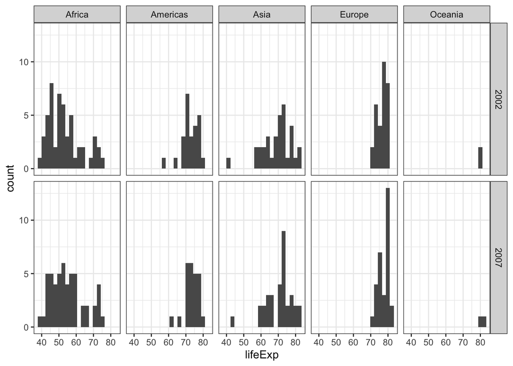

```r
gapdata %>%
  filter(year %in% c(2002, 2007)) %>%
  ggplot(aes(x = lifeExp)) +       # remember aes()
  geom_histogram(bins = 20) +      # histogram with 20 bars
  facet_grid(year ~ continent)
```

What can we see? - life expectancy in Africa is lower than in other regions. - we have little data for Oceania given there are only two countries included, Australia and New Zealand. - Africa and Asia have greater variability in life expectancy by country than in the Americas or Europe. - the data follow a reasonably normal shape, with Africa 2002 a little right skewed.

#### Quantile-quantile (Q-Q) plot

A Q-Q plot is a graphical method for comparing the distribution (think shape) of our own data to a theoretical distribution, such as the normal distribution.

A Q-Q plot simply plots the quantiles for our data against the theoretical quantiles for a particular distribution (the default shown below is the normal distribution). If our data follow that distribution (e.g., normal), then our data points fall on the theoretical straight line.

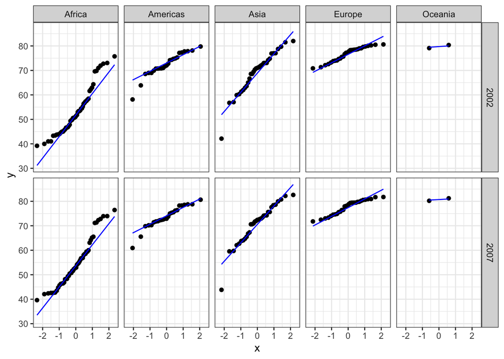

```r
gapdata %>%
  filter(year %in% c(2002, 2007)) %>%
  ggplot(aes(sample = lifeExp)) +      # Q-Q plot requires 'sample'
  geom_qq() +                          # defaults to normal distribution
  geom_qq_line(colour = "blue") +      # add the theoretical line
  facet_grid(year ~ continent)
```

What can we see? We are looking to see if the data (dots) follow the straight line which we included in the plot. These do reasonably, except for Africa which is curved upwards at each end. This is the right skew we could see on the histograms too. If your data do not follow a normal distribution, then you should avoid using a t-test or ANOVA when comparing groups. Non-parametric tests are one alternative.

#### Boxplots

Boxplots are our preferred method for comparing a continuous variable such as life expectancy across a categorical explanatory variable. For continuous data, box plots are a lot more appropriate than bar plots with error bars (also known as dynamite plots).

- The box represents the median (bold horizontal line in the middle) and interquartile range (where 50% of the data sits).
- The lines (whiskers) extend to the lowest and highest values that are still within 1.5 times the interquartile range.
- Outliers (anything outwith the whiskers) are represented as points.

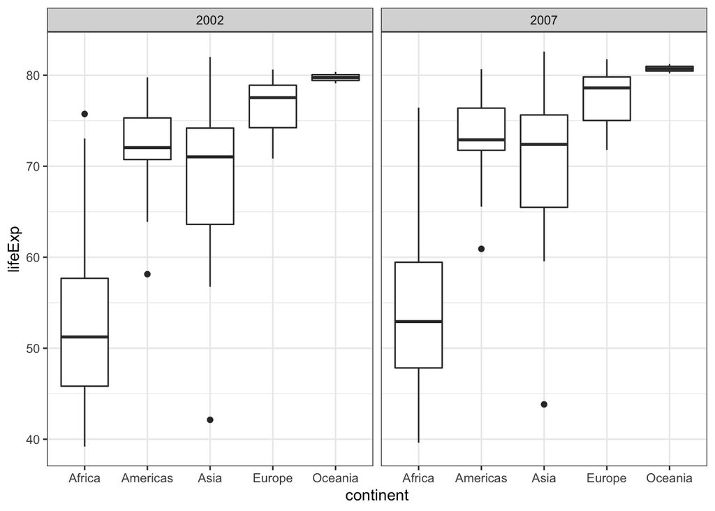

```r
gapdata %>%
  filter(year %in% c(2002, 2007)) %>%
  ggplot(aes(x = continent, y = lifeExp)) +
  geom_boxplot() +
  facet_wrap(~ year)
```

The median life expectancy is lower in Africa than in any other continent. The variation in life expectancy is greatest in Africa and smallest in Oceania. The data in Africa looks skewed, particularly in 2002 - the lines/whiskers are unequal lengths.

### Cheat Sheet for comparing continuous data

| *normal distribution?* | Two groups | Paired? | Multiple groups |
| --- | --- | --- | --- |
| Yes - parametric tests | *t*-test | paired *t-*test | one-way ANOVA |
| No - nonparametric tests | Mann-Whitney U test | Wilcoxon signed-rank test | Kruskal-Wallis test |

### *t-*test

A *t*-test is used to compare the means of two groups of continuous measurements. We will discuss two types of *t-*test here.

#### Two-sample *t*-tests

We would like to compare the life expectancy in Asian countries and European countries in the year 2007. We assume that the mean life expectancy of each country does not depend on the life expectancies of other countries in the group. In other words, that each measurement is independent.

```r
ttest_data <- gapdata %>%                    # save as object ttest_data
  filter(year == 2007) %>%                   # 2007 only
  filter(continent %in% c("Asia", "Europe")) # Asia/Europe only

ttest_result <- ttest_data %>%               # example using pipe
  t.test(lifeExp ~ continent, data = .)      # note data = ., see below
ttest_result
```

```
##
##  Welch Two Sample t-test
##
## data:  lifeExp by continent
## t = -4.6468, df = 41.529, p-value = 3.389e-05
## alternative hypothesis: true difference in means between group Asia and group Europe is not equal to 0
## 95 percent confidence interval:
##  -9.926525 -3.913705
## sample estimates:
##   mean in group Asia mean in group Europe
##             70.72848             77.64860
```

The p-value can be accessed as:

```r
ttest_result$p.value
```

```
## [1] 3.38922e-05
```

The confidence interval of the difference in mean life expectancy between the two continents:

```r
ttest_result$conf.int
```

```
## [1] -9.926525 -3.913705
## attr(,"conf.level")
## [1] 0.95
```

#### Paird *t-*test

Consider that we want to compare the difference in life expectancy in Asian countries between 2002 and 2007. The overall difference is not impressive in the boxplot.

We can plot differences at the country level directly.

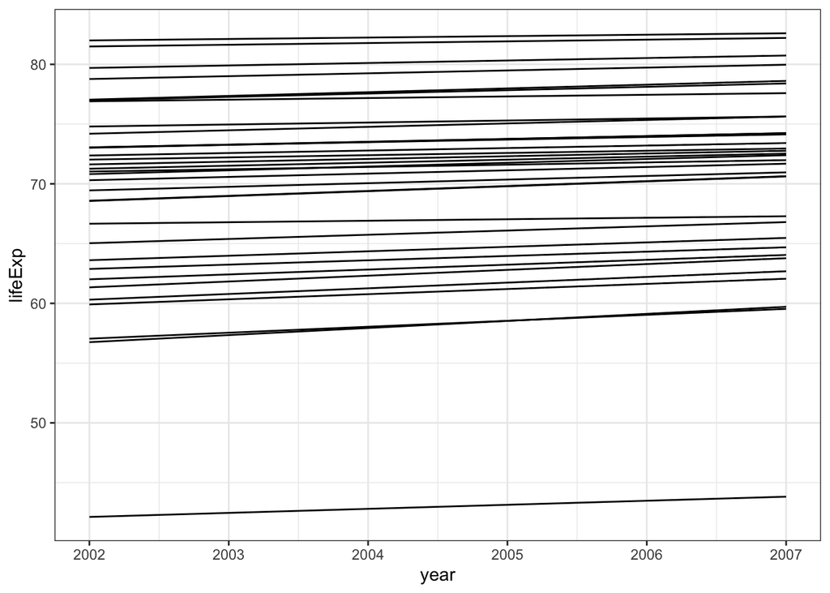

```r
paired_data <- gapdata %>%             # save as object paired_data
  filter(year %in% c(2002, 2007)) %>%  # 2002 and 2007 only
  filter(continent == "Asia")          # Asia only

paired_data %>%
  ggplot(aes(x = year, y = lifeExp,
             group = country)) +       # for individual country lines
  geom_line()
```

To perform the paired *t-*test:

```r
paired_data %>%
  t.test(lifeExp ~ year, data = ., paired = TRUE)
```

```
##
##  Paired t-test
##
## data:  lifeExp by year
## t = -14.338, df = 32, p-value = 1.758e-15
## alternative hypothesis: true difference in means is not equal to 0
## 95 percent confidence interval:
##  -1.706941 -1.282271
## sample estimates:
## mean of the differences
##               -1.494606
```

The results show a highly significant difference (*p*-value = 0.000000000000002). The average difference of 1.5 years is highly consistent between countries, as shown on the line plot, and this differs from zero. It is up to you the investigator to interpret the relevance of the effect size of 1.5 years in reporting the finding. A highly significant *p*-value does not necessarily mean there is a (clinically) significant change between the two groups (or in this example, two time points).

#### What if I run the wrong test?

Try out the non-paired *t-*test with the `paired_data`.

```r
paired_data %>%
  t.test(lifeExp ~ year, data = .)
```

```
##
##  Welch Two Sample t-test
##
## data:  lifeExp by year
## t = -0.74294, df = 63.839, p-value = 0.4602
## alternative hypothesis: true difference in means between group 2002 and group 2007 is not equal to 0
## 95 percent confidence interval:
##  -5.513722  2.524510
## sample estimates:
## mean in group 2002 mean in group 2007
##           69.23388           70.72848
```

### One sample *t-*test

Sometimes we only have one group and want to ask if the mean of the group is significantly different from a given value. For instance, we can test whether the mean life expectancy in each continent was significantly different from 77 years in 2007.

```r
library(broom)
gapdata %>%
  filter(year == 2007) %>%          # 2007 only
  group_by(continent) %>%           # split by continent
  do(                               # dplyr function
    t.test(.$lifeExp, mu = 77) %>%  # compare mean to 77 years
      tidy()                        # tidy into tibble
  )
```

```
## # A tibble: 5 × 9
## # Groups:   continent [5]
##   continent estimate statistic  p.value parameter conf.low conf.high method
##   <fct>        <dbl>     <dbl>    <dbl>     <dbl>    <dbl>     <dbl> <chr>
## 1 Africa        54.8    -16.6  3.15e-22        51     52.1      57.5 One Sample…
## 2 Americas      73.6     -3.82 8.32e- 4        24     71.8      75.4 One Sample…
## 3 Asia          70.7     -4.52 7.88e- 5        32     67.9      73.6 One Sample…
## 4 Europe        77.6      1.19 2.43e- 1        29     76.5      78.8 One Sample…
## 5 Oceania       80.7      7.22 8.77e- 2         1     74.2      87.3 One Sample…
## # … with 1 more variable: alternative <chr>
```

The mean life expectancy for Europe and Oceania do not significantly differ from 77, while the others do. In particular, look at the confidence intervals of the results above (`conf.low` and `conf.high` columns) and whether they include or exclude 77. For instance, Oceania’s confidence intervals are especially wide as the dataset only includes two countries. Therefore, we can’t conclude that its value isn’t different to 77, but that we don’t have enough observations and the estimate is uncertain. It doesn’t make sense to report the results of a statistical test - whether the *p*-value is significant or not - without assessing the confidence intervals.

### One-way ANOVA

We often need to compare the mean of more than two groups. For example, we may be interested in comparing life expectancy across 3 continents such as the Americas, Europe and Asia.

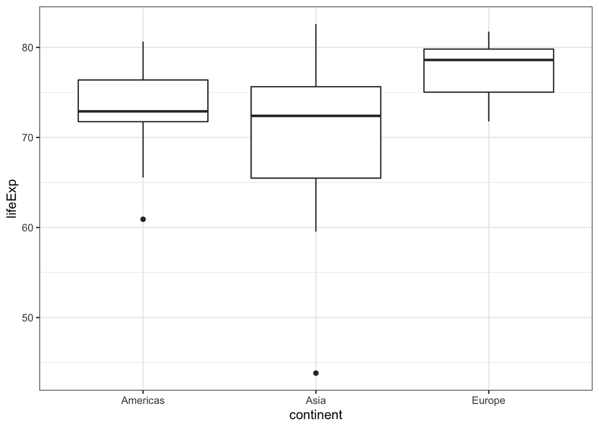

```r
gapdata %>%
  filter(year == 2007) %>%
  filter(continent %in%
           c("Americas", "Europe", "Asia")) %>%
  ggplot(aes(x = continent, y=lifeExp)) +
  geom_boxplot()
```

Analysis of variance (ANOVA) is a collection of statistical tests which can be used to test the difference in means between two or more groups.

In base R form, it produces an ANOVA table which includes an F-test. This so-called omnibus test tells you whether there are any differences in the comparison of means of the included groups. Again, it is important to plot carefully and be clear what question you are asking.

```r
aov_data <- gapdata %>%
  filter(year == 2007) %>%
  filter(continent %in% c("Americas", "Europe", "Asia"))

fit = aov(lifeExp ~ continent, data = aov_data)
summary(fit)
```

```
##             Df Sum Sq Mean Sq F value   Pr(>F)
## continent    2  755.6   377.8   11.63 3.42e-05 ***
## Residuals   85 2760.3    32.5
## ---
## Signif. codes:  0 '***' 0.001 '**' 0.01 '*' 0.05 '.' 0.1 ' ' 1
```

We can conclude from the significant F-test that the mean life expectancy across the three continents is not the same. This does not mean that all included groups are significantly different from each other.

### Non-parametric tests

If your data is a different shape to normal, or the ANOVA assumptions are not fulfilled, you can perform non-parametric tests.

#### Non-parametric test for comparing two groups

The Mann-Whitney U test is also called the Wilcoxon rank-sum test and uses a rank-based method to compare two groups (note the Wilcoxon signed-rank test is for paired data). Rank-based just means ordering your grouped continuous data from smallest to largest value and assigning a rank (1, 2, 3 …) to each measurement.

We can use it to test for a difference in life expectancies for African countries between 1982 and 2007. Let’s do a histogram, Q-Q plot and boxplot first.

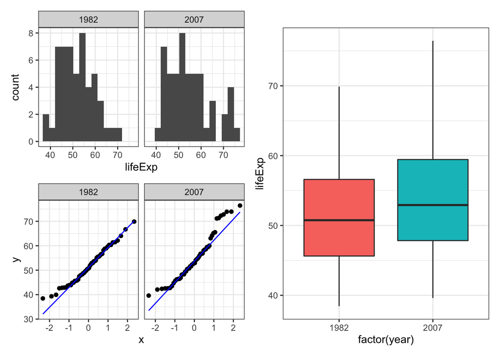

```r
africa_data <- gapdata %>%
  filter(year %in% c(1982, 2007)) %>%      # only 1982 and 2007
  filter(continent %in% c("Africa"))       # only Africa

p1 <- africa_data %>%                      # save plot as p1
  ggplot(aes(x = lifeExp)) +
  geom_histogram(bins = 15) +
  facet_wrap(~year)

p2 <- africa_data %>%                      # save plot as p2
  ggplot(aes(sample = lifeExp)) +          # `sample` for Q-Q plot
  geom_qq() +
  geom_qq_line(colour = "blue") +
  facet_wrap(~year)

p3 <- africa_data %>%                      # save plot as p3
  ggplot(aes(x = factor(year),             # try without factor(year) to
             y = lifeExp)) +               # see the difference
  geom_boxplot(aes(fill = factor(year))) + # colour boxplot
  theme(legend.position = "none")          # remove legend

library(patchwork)                         # great for combining plots
p1 / p2 | p3
```

The data is a little skewed based on the histograms and Q-Q plots. The difference between 1982 and 2007 is not particularly striking on the boxplot.

```r
africa_data %>%
  wilcox.test(lifeExp ~ year, data = .)
```

```
##
##  Wilcoxon rank sum test with continuity correction
##
## data:  lifeExp by year
## W = 1130, p-value = 0.1499
## alternative hypothesis: true location shift is not equal to 0
```

We can also do paired test.

```r
africa_data %>%
  wilcox.test(lifeExp ~ year, data = ., paired = T)
```

```
##
##  Wilcoxon signed rank test with continuity correction
##
## data:  lifeExp by year
## V = 367, p-value = 0.003413
## alternative hypothesis: true location shift is not equal to 0
```

#### Non-parametric test for comparing more than two groups

The non-parametric equivalent to ANOVA, is the Kruskal-Wallis test.

```r
gapdata %>%
  filter(year == 2007) %>%
  filter(continent %in% c("Americas", "Europe", "Asia")) %>%
  kruskal.test(lifeExp~continent, data = .)
```

```
##
##  Kruskal-Wallis rank sum test
##
## data:  lifeExp by continent
## Kruskal-Wallis chi-squared = 21.618, df = 2, p-value = 2.021e-05
```

### Plotting statistically tests with your plot, including pairwise comparison.

Use `ggpubr` to plot the statistically tests on your boxplot.

Here is an example

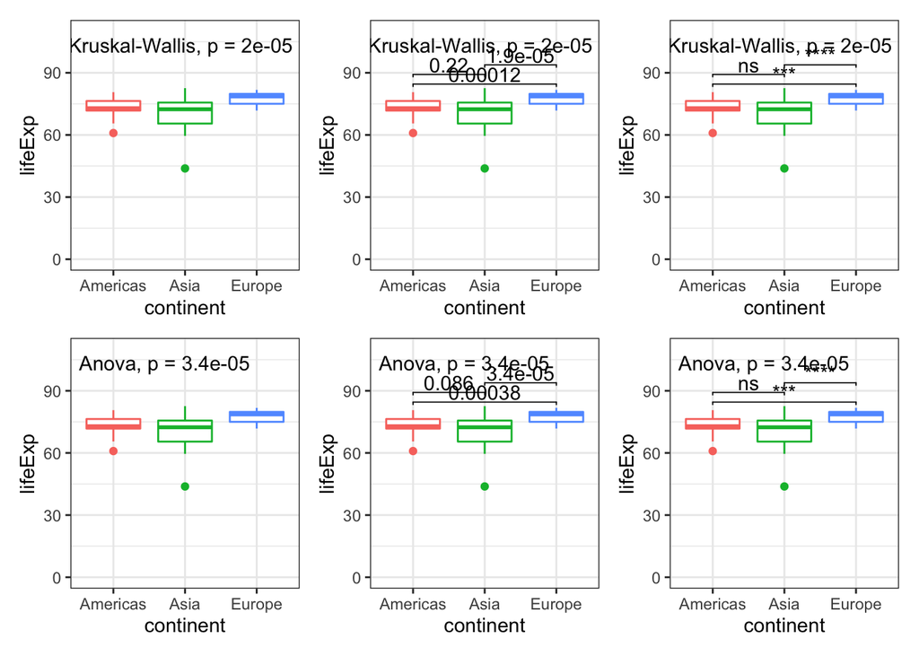

```r
p0 <- gapdata %>%
  filter(year == 2007) %>%
  filter(continent %in%
           c("Americas", "Europe", "Asia")) %>%
  ggplot(aes(x = continent, y=lifeExp, color = continent)) +
  ylim(0, 110) +
  geom_boxplot() +
  theme(legend.position = 'none')


p1 <- p0 +
  stat_compare_means(label.y = 100) # from ggpubr

p2 <- p0 +
  stat_compare_means(method = 'anova', label.y = 100) # from ggpubr

# set comparisons
my_comparisons <- list( c("Americas", "Europe"), c("Americas", "Asia"), c("Europe", "Asia"))

p3 <- p0 +
  stat_compare_means(comparisons = my_comparisons) +
  stat_compare_means(label.y = 100)

p4 <- p0 +
  stat_compare_means(comparisons = my_comparisons, method = "t.test") +
  stat_compare_means(method = 'anova', label.y = 100)

p5 <- p0 +
  stat_compare_means(comparisons = my_comparisons, label = "p.signif" ) +
  stat_compare_means(label.y = 100)

p6 <- p0 +
  stat_compare_means(comparisons = my_comparisons, method = "t.test", label = "p.signif") +
  stat_compare_means(method = 'anova', label.y = 100)

p1 + p3 + p5 + p2 + p4 + p6
```

### Conclusions:

**Simply use non-parametric tests for all analysis.**